# Yuma Cove Backwater Razorback Sucker — three-stage robust-design model validation

Phase 3: convergence, known-alive constraints, survival floors, and posterior predictive checks

Author

Marsh & Associates

Published

September 8, 2026

## Purpose and fit being validated

This document validates the current working variant of the three-stage (S / L / A) density-dependent robust-design model for Razorback Sucker in Yuma Cove Backwater (YCB), fitted by `model/YCB3S_NIMBLE.R` and saved as `data/YCB3S_MCMC_m12.RData`. The fit uses the **m12** calendar: every month October–September is a primary period (12 per season, 120 in total), so May–September scanning provides detections as well as known-alive constraints. Where useful, the m7 (Oct–Apr) fit (`data/YCB3S_MCMC.RData`) is shown alongside for comparison. It follows the Phase 3 checklist in the plan file:

1. Convergence (R-hat, effective sample size) for hyperparameters and for the abundance and recruitment nodes.
2. Constraint check: modeled tagged abundance must be at least the number of fish known alive by any PIT contact in every month.
3. Posterior annual survival by stage against empirical re-sighting floors, including the FY2021–FY2022 scanner gap treated as a single span.
4. Posterior predictive checks for the recruit size split (`sp_nL`) and the netting join (`ev_m`).
5. Parameter summary and the density–size relationship, with a comparison to the joint two-stage fit where available.

| Item | Value |
| --- | --- |
| Fit completed | 2026-09-08 16:41 |
| Data build | 2026-09-08 15:32 |
| Calendar / primaries | m12 / 120 |
| Chains | 3 |
| Iterations / burn-in / thin | 30000 / 10000 / 10 |
| Retained draws | 6000 |
| Wall time (min) | 59.1 |
| Stage breaks (XYTE, mm TL) | 300, 350 |
| Variant | 12-month calendar (May-Sep months are primaries); shared juvenile detection: lp[j, 2] <- lp[j, 1]; b_postJ tied to b_post; season-specific juvenile deviation eps_J[j, y] on lphiL, centered: eps_J = ep… |

Species index 2 (Bonytail) is present in the model code but has no data in this single-pond build; those parameters are prior-only and are omitted throughout.

## 1. Convergence

R-hat and effective sample size by node family (species 1 only)

| family | nodes | max R-hat | nodes > 1.1 | min n.eff |
| --- | --- | --- | --- | --- |
| U | 30 | 1.288 | 3 | 505 |
| r | 9 | 1.287 | 2 | 542 |
| RecJ | 9 | 1.285 | 2 | 538 |
| N_tag | 357 | 1.148 | 15 | 68 |
| Tal | 27 | 1.147 | 3 | 70 |
| eps_J | 10 | 1.101 | 1 | 104 |
| lphiL | 10 | 1.066 | 0 | 148 |
| lphiS | 10 | 1.065 | 0 | 148 |
| b_post | 2 | 1.044 | 0 | 195 |
| lphiA | 10 | 1.038 | 0 | 173 |
| dJ | 1 | 1.034 | 0 | 104 |
| d_moy | 22 | 1.027 | 0 | 313 |
| dS | 1 | 1.024 | 0 | 672 |
| lp | 3 | 1.024 | 0 | 195 |
| sigma_J | 1 | 1.014 | 0 | 636 |
| nu | 1 | 1.009 | 0 | 3265 |
| lpsiLA | 1 | 1.007 | 0 | 140 |
| lpsiSL | 1 | 1.006 | 0 | 82 |
| Atot | 9 | 1.005 | 0 | 1122 |
| U0 | 3 | 1.005 | 0 | 1122 |
| sigma_phi | 1 | 1.005 | 0 | 934 |
| mu_phi | 1 | 1.003 | 0 | 1747 |
| g_eff | 1 | 1.002 | 0 | 2742 |
| mu_r | 1 | 1.002 | 0 | 2538 |
| a0 | 1 | 1.000 | 0 | 5020 |
| a1 | 1 | 1.000 | 0 | 4737 |
| pLg | 10 | 1.000 | 0 | 4642 |
| sigma_r | 1 | 1.000 | 0 | 1235 |

Nodes with R-hat > 1.1

| node | Rhat | n_eff | family | sp2 |
| --- | --- | --- | --- | --- |
| U[1, 10, 2] | 1.288 | 5665 | U | FALSE |
| r[1, 9] | 1.287 | 5735 | r | FALSE |
| RecJ[1, 9] | 1.285 | 5755 | RecJ | FALSE |
| U[1, 10, 1] | 1.274 | 5850 | U | FALSE |
| RecJ[1, 4] | 1.272 | 6000 | RecJ | FALSE |
| U[1, 5, 1] | 1.271 | 6000 | U | FALSE |
| r[1, 4] | 1.270 | 6000 | r | FALSE |
| N_tag[1, 84, 3] | 1.148 | 574 | N_tag | FALSE |
| N_tag[1, 86, 2] | 1.147 | 646 | N_tag | FALSE |
| Tal[24] | 1.147 | 646 | Tal | FALSE |
| N_tag[1, 85, 2] | 1.146 | 611 | N_tag | FALSE |
| N_tag[1, 61, 2] | 1.140 | 570 | N_tag | FALSE |
| Tal[18] | 1.140 | 570 | Tal | FALSE |
| N_tag[1, 60, 2] | 1.139 | 548 | N_tag | FALSE |
| N_tag[1, 59, 2] | 1.136 | 534 | N_tag | FALSE |
| N_tag[1, 84, 2] | 1.136 | 398 | N_tag | FALSE |
| N_tag[1, 58, 2] | 1.133 | 516 | N_tag | FALSE |
| N_tag[1, 57, 2] | 1.130 | 499 | N_tag | FALSE |
| N_tag[1, 80, 3] | 1.125 | 504 | N_tag | FALSE |
| N_tag[1, 81, 3] | 1.124 | 508 | N_tag | FALSE |
| N_tag[1, 82, 3] | 1.124 | 526 | N_tag | FALSE |
| N_tag[1, 83, 3] | 1.122 | 587 | N_tag | FALSE |
| N_tag[1, 56, 2] | 1.121 | 462 | N_tag | FALSE |
| N_tag[1, 86, 3] | 1.106 | 312 | N_tag | FALSE |
| Tal[25] | 1.106 | 312 | Tal | FALSE |
| eps_J[1, 7] | 1.101 | 167 | eps_J | FALSE |

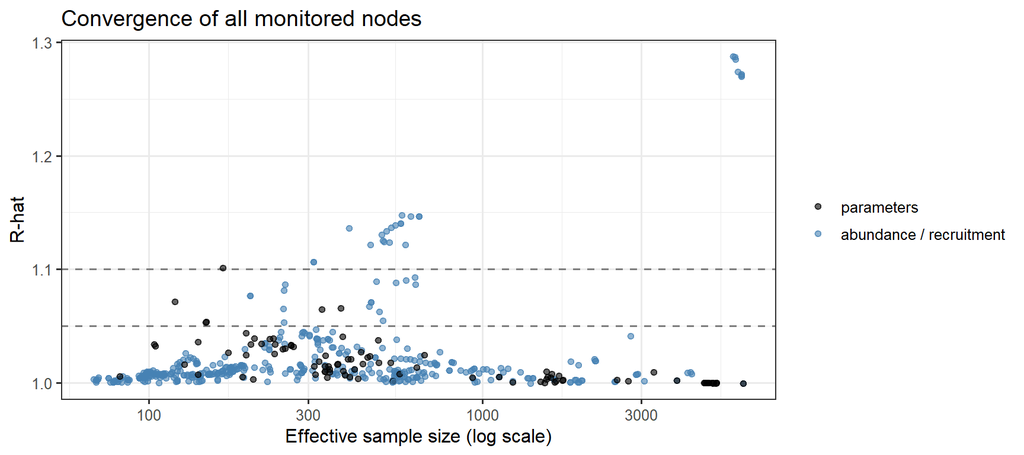

The nodes with the poorest mixing are expected to be final-season quantities (FY2026 is partial, with only seven recruits measured at the October 2025 netting) and last-season recruitment, which is weakly identified. Anything outside that set that exceeds 1.1 should be checked against the traceplots in `model/YCB3S_traceplots_m12.pdf`.

## 2. Constraint check: modeled tagged abundance vs known alive

For each primary month, a fish is *known alive* if it entered the model at or before that month, had not been removed, is counted (`count_from`), and had any PIT contact (including May–Sep) in that month or later. The posterior of `sum(N_tag[t, ])` must be at least this count; the check is applied to both the posterior mean and the lower 2.5 % bound.

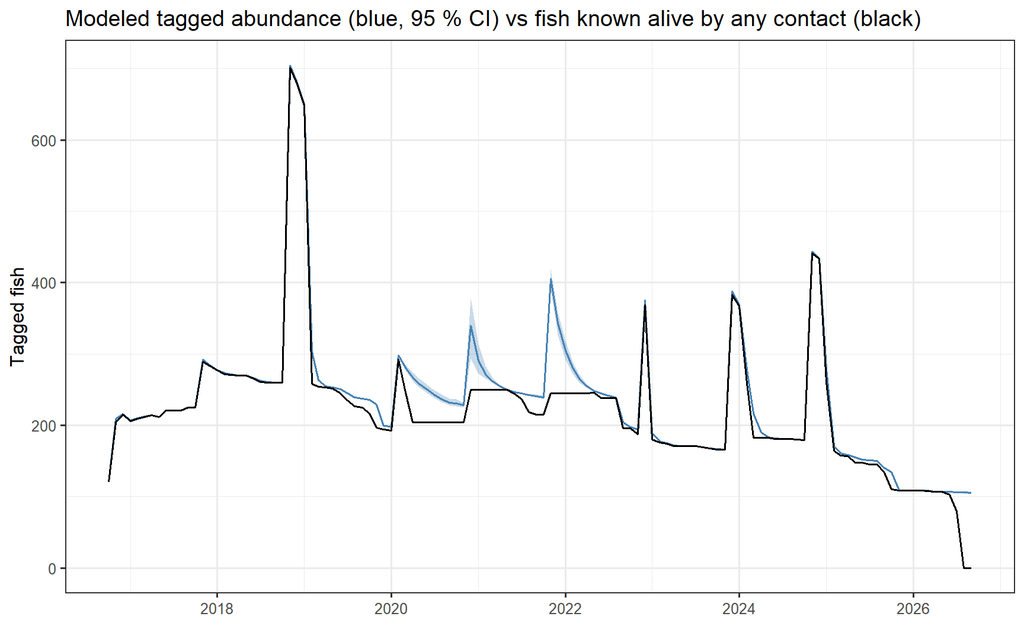

| Check | Value |
| --- | --- |
| Months evaluated | 120 |
| Months where lower 2.5 % bound < known alive | 0 |
| Months where posterior mean < known alive | 0 |
| Smallest margin (posterior mean − known alive) | 0 |
| Smallest margin (2.5 % bound − known alive) | 0 |

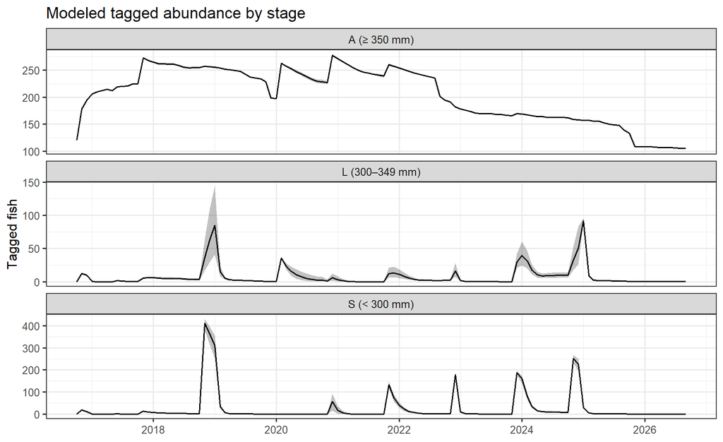

## 3. Survival by stage vs empirical re-sighting floors

### 3.1 Adults, by season

Posterior annual adult survival (12 months at the season's monthly rate) vs empirical re-sighting floor

| Season | Adults alive Oct | Re-seen ≥ next Oct | Floor | Model mean | 2.5 % | 97.5 % | Model − floor |  |
| --- | --- | --- | --- | --- | --- | --- | --- | --- |
| FY2017 | 120 | 110 | 0.917 | 0.903 | 0.863 | 0.935 | -0.014 |  |
| FY2018 | 224 | 200 | 0.893 | 0.901 | 0.870 | 0.929 | 0.008 |  |
| FY2019 | 246 | 202 | 0.821 | 0.856 | 0.814 | 0.890 | 0.034 |  |
| FY2020 | 194 | 167 | 0.861 | 0.933 | 0.903 | 0.957 | 0.072 |  |
| FY2021 | 190 | 160 | 0.842 | 0.865 | 0.821 | 0.904 | 0.023 |  |
| FY2022 | 207 | 163 | 0.787 | 0.779 | 0.730 | 0.824 | -0.009 |  |
| FY2023 | 176 | 154 | 0.875 | 0.851 | 0.803 | 0.896 | -0.024 |  |
| FY2024 | 159 | 148 | 0.931 | 0.909 | 0.871 | 0.941 | -0.022 |  |
| FY2025 | 151 | 104 | 0.689 | 0.837 | 0.782 | 0.885 | 0.148 |  |
| FY2026 | NA | NA | NA | 0.939 | 0.886 | 0.978 | NA |  |

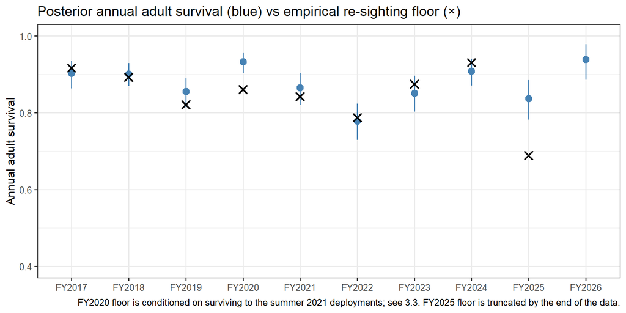

### 3.2 Netting-tagged juveniles, by cohort

For each fall cohort of netting-tagged fish that entered at < 350 mm, the floor is the fraction contacted at or after the following October. The model-implied comparison is survival over the calendar months from the netting to the next October, using the post-release rate (`lphiS + b_post[1, 2]`) for the first six months and the S-stage rate afterwards; maturation into L or A during that span (which raises survival) is ignored, so the model curve is a slight underestimate of what the model actually implies. The last columns give the same quantity from the m7 (Oct–Apr) fit over the same calendar span.

Netting-tagged juvenile cohorts: fraction re-seen at or after the next October vs model-implied survival over the same span (m12 (all months) fit)

| Cohort | Recruits handled | Tagged < 350 mm | Re-seen | Months to next Oct | Floor | Model mean | 2.5 % | 97.5 % | m7 (Oct–Apr) fit mean | m7 (Oct–Apr) fit 2.5 % | m7 (Oct–Apr) fit 97.5 % |
| --- | --- | --- | --- | --- | --- | --- | --- | --- | --- | --- | --- |
| FY2017 | 120 | 116 | 2 | 12 | 0.017 | 0.000 | 0.000 | 0.001 | 0.000 | 0.000 | 0.000 |
| FY2018 | 40 | 40 | 15 | 12 | 0.375 | 0.176 | 0.064 | 0.326 | 0.195 | 0.077 | 0.357 |
| FY2019 | 484 | 484 | 3 | 12 | 0.006 | 0.085 | 0.063 | 0.109 | 0.060 | 0.040 | 0.082 |
| FY2021 | 230 | 230 | 0 | 11 | 0.000 | 0.000 | 0.000 | 0.001 | 0.001 | 0.000 | 0.007 |
| FY2022 | 245 | 245 | 5 | 12 | 0.020 | 0.016 | 0.005 | 0.034 | 0.044 | 0.014 | 0.086 |
| FY2023 | 1283 | 283 | 0 | 11 | 0.000 | 0.001 | 0.000 | 0.003 | 0.001 | 0.000 | 0.001 |
| FY2024 | 366 | 266 | 21 | 11 | 0.079 | 0.095 | 0.067 | 0.128 | 0.096 | 0.063 | 0.134 |
| FY2025 | 829 | 298 | 1 | 12 | 0.003 | 0.025 | 0.015 | 0.038 | 0.016 | 0.009 | 0.027 |

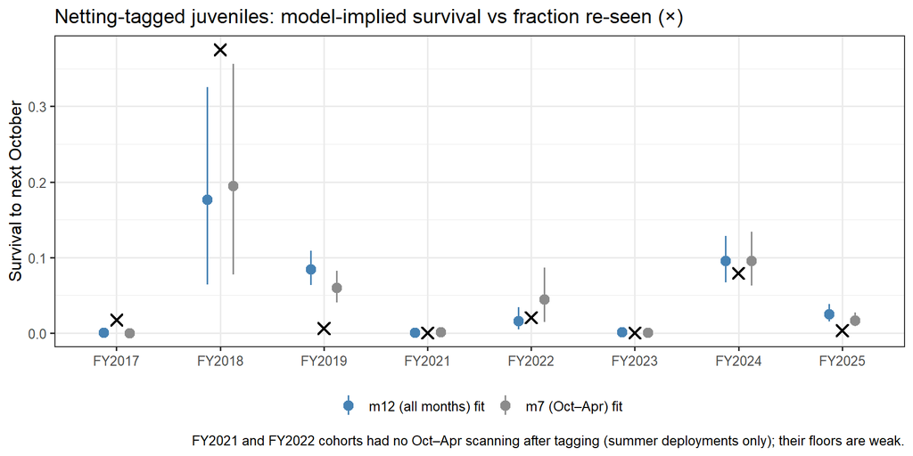

### 3.3 The FY2021–FY2022 scanner gap

There was no Oct–Apr scanning at YCB between April 2020 and October 2022 apart from one week at the end of April 2021. Scanners *were* deployed in the intervening summers — submersible units from 30 April to 4 August 2021 (~2,300 scan hours, 200 fish contacted in May 2021), 10–18 May 2022 (~760 hours, 239 fish), and 3 August to 22 September 2022 (~2,200 hours, 222 fish). Under the 12-month calendar those summer months are primary periods with detections, so lphiA for FY2021 and FY2022 are informed directly and the summer-to-summer interval (May–Jul 2021 → May–Sep 2022) is a scanned-to-scanned span the model must match. Two spans are reported: October 2020 → October 2022 (24 months) and, because the naive October 2020 floor is conditioned on having been seen afterwards, the last well-scanned month March 2020 → October 2022 (31 months: 7 months at the FY2020 rate, then 12 + 12).

Adult survival across the scanner gap

| Span | Adults alive at start | Re-seen after end | Floor | Model mean | 2.5 % | 97.5 % |
| --- | --- | --- | --- | --- | --- | --- |
| Oct 2020 → Oct 2022 (24 mo) | 190 | 121 | 0.637 | 0.674 | 0.623 | 0.722 |
| Mar 2020 → Oct 2022 (31 mo) | 221 | 121 | 0.548 | 0.647 | 0.598 | 0.694 |

The 24-month floor is biased upward because, with no Oct–Apr scanning inside the window, being “known alive” in October 2020 mostly means having been contacted after October 2022. The 31-month floor avoids that and is the appropriate comparison; a model estimate above it indicates that the loss inside the gap cannot be placed where it happened.

Gap decomposition: direct floors on the March 2020 adult cohort vs the model's season-constant monthly rates over each leg

| Leg | Adults at start | Seen at end | Floor | Model mean | 2.5 % | 97.5 % | Model − floor |
| --- | --- | --- | --- | --- | --- | --- | --- |
| Mar 2020 → May–Jul 2021 | 221 | 181 | 0.819 | 0.883 | 0.854 | 0.909 | 0.064 |
| May–Jul 2021 → May–Sep 2022 | 181 | 152 | 0.840 | 0.814 | 0.780 | 0.844 | -0.026 |
| May–Sep 2022 → ≥ Oct 2022 | 152 | 115 | 0.757 | 0.901 | 0.877 | 0.923 | 0.144 |
| Mar 2020 → ≥ Oct 2022 (whole) | 221 | 121 | 0.548 | 0.647 | 0.598 | 0.694 | 0.100 |

The middle leg is bounded by scanning at both ends and is where the 12-month calendar adds information; the model should match its floor closely. The first leg spans April 2020 → April 2021 with no scanning at all, and the third contains the late-summer 2022 loss that a season-constant monthly rate spreads over all of FY2022 — for both, the model can only shrink toward the season mean, so the direct floors are the better estimate and should be what is reported for those stretches.

### 3.4 Season-specific juvenile deviations

Centered season deviation eps_J on juvenile (L-stage) survival and the implied annual L-stage survival (12 months, no post-release offset)

| Season | Recruits handled | eps_J mean | 2.5 % | 97.5 % | Annual phi_L | 2.5 % | 97.5 % | R-hat |
| --- | --- | --- | --- | --- | --- | --- | --- | --- |
| FY2017 | 120 | -1.437 | -1.983 | -0.837 | 0.009 | 0.001 | 0.033 | 1.026 |
| FY2018 | 40 | 0.567 | 0.013 | 1.137 | 0.431 | 0.245 | 0.614 | 1.003 |
| FY2019 | 484 | 0.604 | 0.166 | 1.013 | 0.302 | 0.211 | 0.396 | 1.032 |
| FY2020 | 2887 | 1.417 | 0.526 | 2.447 | 0.767 | 0.523 | 0.920 | 1.041 |
| FY2021 | 230 | -1.541 | -2.943 | -0.702 | 0.004 | 0.000 | 0.025 | 1.024 |
| FY2022 | 245 | 0.453 | -0.014 | 0.917 | 0.120 | 0.049 | 0.215 | 1.034 |
| FY2023 | 1283 | -0.638 | -1.109 | -0.208 | 0.024 | 0.007 | 0.054 | 1.101 |
| FY2024 | 366 | 0.108 | -0.372 | 0.543 | 0.305 | 0.209 | 0.402 | 1.036 |
| FY2025 | 829 | 0.263 | -0.215 | 0.686 | 0.157 | 0.089 | 0.236 | 1.016 |
| FY2026 | 7 | 0.205 | -1.662 | 2.495 | 0.477 | 0.007 | 0.940 | 1.071 |

## 4. Posterior predictive checks

### 4.1 Recruit size split (`sp_nL ~ Binomial(n0, pLg)`)

Observed recruits ≥ 300 mm vs posterior predictive distribution (two-sided tail probability; small values indicate misfit); m12 (all months) fit

| Season | Measured (n0) | Observed ≥ 300 | Observed pL | Posterior pLg | PP 2.5 % | PP median | PP 97.5 % | PP p-value | m7 (Oct–Apr) fit pLg | m7 (Oct–Apr) fit PP p-value |
| --- | --- | --- | --- | --- | --- | --- | --- | --- | --- | --- |
| FY2018 | 40 | 6 | 0.150 | 0.183 | 2 | 7 | 13 | 0.824 | 0.185 | 0.795 |
| FY2019 | 484 | 0 | 0.000 | 0.015 | 2 | 7 | 14 | 0.002 | 0.016 | 0.004 |
| FY2020 | 2887 | 10 | 0.003 | 0.002 | 2 | 6 | 13 | 0.348 | 0.002 | 0.403 |
| FY2021 | 230 | 2 | 0.009 | 0.033 | 3 | 7 | 14 | 0.043 | 0.034 | 0.043 |
| FY2022 | 245 | 1 | 0.004 | 0.031 | 3 | 7 | 14 | 0.011 | 0.032 | 0.008 |
| FY2023 | 283 | 1 | 0.004 | 0.005 | 0 | 1 | 4 | 1.000 | 0.006 | 1.000 |
| FY2024 | 366 | 26 | 0.071 | 0.020 | 2 | 7 | 14 | 0.000 | 0.021 | 0.000 |
| FY2025 | 829 | 3 | 0.004 | 0.009 | 2 | 7 | 14 | 0.178 | 0.009 | 0.145 |
| FY2026 | 7 | 7 | 1.000 | 0.558 | 1 | 4 | 7 | 0.062 | 0.559 | 0.060 |

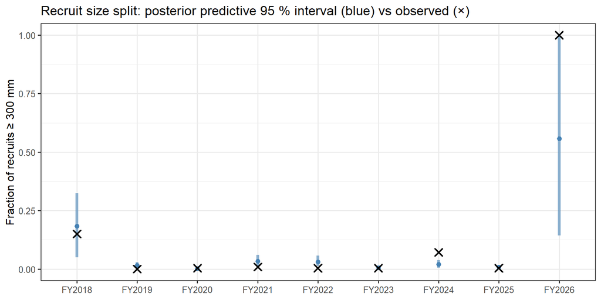

### 4.2 Density–size relationship

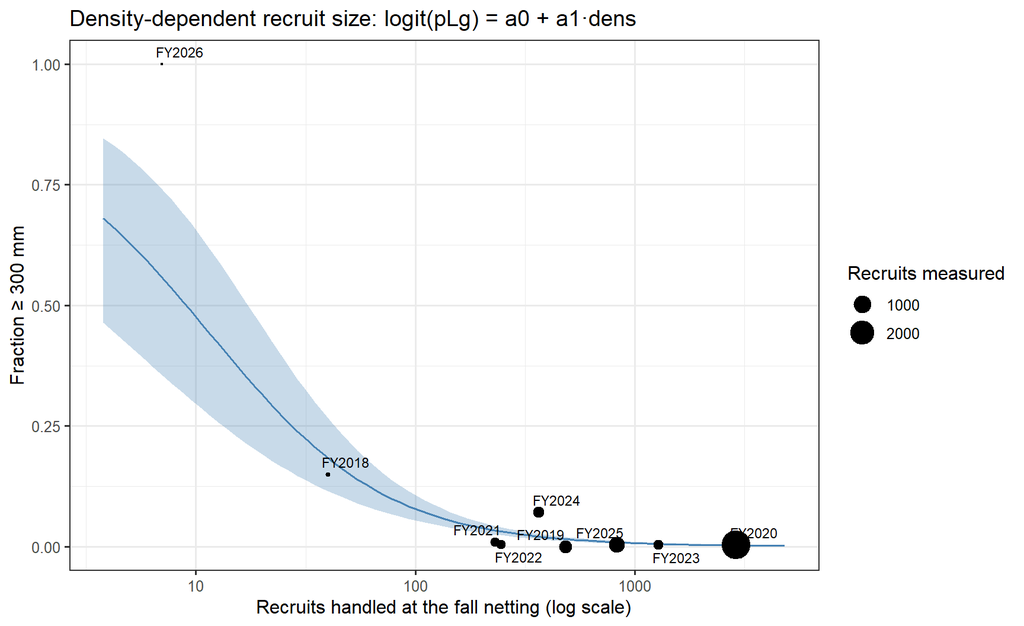

| Parameter | Mean | 2.5 % | 97.5 % |
| --- | --- | --- | --- |
| a0 (logit pL at mean log density) | -3.492 | -3.769 | -3.215 |
| a1 (per SD of log recruit density) | -1.842 | -2.192 | -1.492 |

Note that the recruit density covariate is standardized log(recruits + 1) per unit area with `Area = 1` for YCB (surface area not yet available), so `a1` is a per-SD effect of log recruit *number* until `data/BWPondAreas.csv` is populated.

### 4.3 Netting join (`ev_m ~ Binomial(ev_n, N_tag / (N_tag + U_available))`)

Each row is one netting event × stage: `n` fish handled, `m` of them previously tagged. The posterior predictive draws use the monitored `N_tag` at the netting month and the untagged pool `U` for that season less untagged removals earlier in the same season.

Netting events: previously tagged fish among those handled vs posterior predictive

| Season | Event | Stage | Handled | Tagged (obs) | Posterior p | PP 2.5 % | PP median | PP 97.5 % | PP p-value | N_tag | U available |
| --- | --- | --- | --- | --- | --- | --- | --- | --- | --- | --- | --- |
| FY2017 | 2016-10-01 | S (< 300 mm) | 85 | 0 | 0.000 | 0 | 0 | 0 | 1.000 | 0 | 2543 |
| FY2017 | 2016-10-01 | L (300–349 mm) | 35 | 0 | 0.000 | 0 | 0 | 0 | 1.000 | 0 | 2833 |
| FY2017 | 2016-10-01 | A (≥ 350 mm) | 27 | 14 | 0.305 | 4 | 8 | 13 | 0.050 | 120 | 279 |
| FY2017 | 2017-05-01 | S (< 300 mm) | 3 | 0 | 0.000 | 0 | 0 | 0 | 1.000 | 0 | 2458 |
| FY2017 | 2017-05-01 | A (≥ 350 mm) | 16 | 9 | 0.448 | 3 | 7 | 11 | 0.518 | 212 | 266 |
| FY2018 | 2017-10-01 | S (< 300 mm) | 34 | 0 | 0.000 | 0 | 0 | 0 | 1.000 | 0 | 944 |
| FY2018 | 2017-10-01 | L (300–349 mm) | 6 | 0 | 0.001 | 0 | 0 | 0 | 1.000 | 0 | 228 |
| FY2018 | 2017-10-01 | A (≥ 350 mm) | 93 | 36 | 0.476 | 33 | 44 | 56 | 0.200 | 225 | 251 |
| FY2019 | 2018-10-01 | S (< 300 mm) | 484 | 0 | 0.001 | 0 | 0 | 3 | 1.000 | 2 | 1595 |
| FY2019 | 2018-10-01 | A (≥ 350 mm) | 38 | 23 | 0.530 | 14 | 20 | 27 | 0.483 | 255 | 228 |
| FY2020 | 2019-11-01 | S (< 300 mm) | 2877 | 0 | 0.000 | 0 | 0 | 1 | 1.000 | 0 | 10903 |
| FY2020 | 2019-11-01 | L (300–349 mm) | 10 | 0 | 0.003 | 0 | 0 | 1 | 1.000 | 1 | 247 |
| FY2020 | 2019-11-01 | A (≥ 350 mm) | 79 | 37 | 0.500 | 29 | 40 | 50 | 0.716 | 228 | 231 |
| FY2021 | 2020-11-01 | S (< 300 mm) | 228 | 0 | 0.000 | 0 | 0 | 0 | 1.000 | 0 | 12368 |
| FY2021 | 2020-11-01 | L (300–349 mm) | 2 | 0 | 0.001 | 0 | 0 | 0 | 1.000 | 1 | 4206 |
| FY2021 | 2020-11-01 | A (≥ 350 mm) | 112 | 56 | 0.453 | 38 | 51 | 64 | 0.447 | 227 | 278 |
| FY2022 | 2021-10-01 | S (< 300 mm) | 244 | 0 | 0.000 | 0 | 0 | 0 | 1.000 | 0 | 4901 |
| FY2022 | 2021-10-01 | L (300–349 mm) | 1 | 0 | 0.000 | 0 | 0 | 0 | 1.000 | 0 | 184 |
| FY2022 | 2021-10-01 | A (≥ 350 mm) | 65 | 40 | 0.547 | 26 | 36 | 45 | 0.418 | 239 | 200 |
| FY2023 | 2022-11-01 | S (< 300 mm) | 282 | 0 | 0.000 | 0 | 0 | 1 | 1.000 | 1 | 26427 |
| FY2023 | 2022-11-01 | L (300–349 mm) | 2 | 1 | 0.015 | 0 | 0 | 1 | 0.059 | 2 | 450 |
| FY2023 | 2022-11-01 | A (≥ 350 mm) | 44 | 25 | 0.565 | 17 | 25 | 32 | 1.000 | 192 | 150 |
| FY2024 | 2023-11-01 | S (< 300 mm) | 340 | 0 | 0.000 | 0 | 0 | 0 | 1.000 | 0 | 2484 |
| FY2024 | 2023-11-01 | L (300–349 mm) | 26 | 0 | 0.000 | 0 | 0 | 0 | 1.000 | 0 | 376 |
| FY2024 | 2023-11-01 | A (≥ 350 mm) | 20 | 13 | 0.589 | 7 | 12 | 16 | 0.797 | 166 | 118 |
| FY2025 | 2024-10-01 | S (< 300 mm) | 827 | 1 | 0.002 | 0 | 1 | 6 | 1.000 | 7 | 5250 |
| FY2025 | 2024-10-01 | L (300–349 mm) | 4 | 1 | 0.039 | 0 | 0 | 1 | 0.292 | 10 | 441 |
| FY2025 | 2024-10-01 | A (≥ 350 mm) | 66 | 26 | 0.507 | 23 | 34 | 44 | 0.193 | 162 | 162 |
| FY2026 | 2025-10-01 | L (300–349 mm) | 7 | 0 | 0.001 | 0 | 0 | 0 | 1.000 | 1 | 4857 |
| FY2026 | 2025-10-01 | A (≥ 350 mm) | 50 | 25 | 0.498 | 16 | 25 | 34 | 1.000 | 133 | 139 |

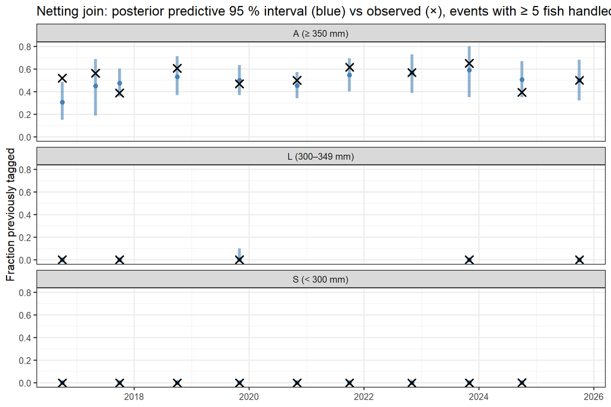

Rows with `Tagged (obs) = 0` and hundreds handled (the S-stage rows) are fit trivially by a large untagged pool; the informative rows are the adult ones, where the tagged fraction pins the ratio of tagged to untagged adults. Small two-sided tail probabilities in the adult rows would indicate that `N_tag` and `U[·, 3]` cannot jointly match the netting data.

## 5. Parameter summary

Core parameters (species 1 = Razorback Sucker) with derived quantities

| Node | Meaning | Mean | 2.5 % | 97.5 % | Derived | Derived mean | Derived 2.5 % | Derived 97.5 % | Rhat | n_eff |
| --- | --- | --- | --- | --- | --- | --- | --- | --- | --- | --- |
| mu_phi[1] | Mean season logit monthly adult survival | 4.578 | 4.196 | 4.981 | annual survival at mu_phi | 0.883 | 0.836 | 0.921 | 1.003 | 1747 |
| sigma_phi[1] | SD of season adult-survival deviations (logit) | 0.556 | 0.294 | 1.005 | NA | NA | NA | NA | 1.005 | 934 |
| dJ[1] | Juvenile (L) offset on logit monthly survival | -2.696 | -3.051 | -2.336 | annual L survival at mu_phi | 0.189 | 0.066 | 0.347 | 1.034 | 104 |
| dS[1] | Small-juvenile (S) additional offset | -0.017 | -0.071 | 0.000 | annual S survival at mu_phi | 0.185 | 0.063 | 0.340 | 1.024 | 672 |
| sigma_J[1] | SD of season juvenile deviations eps_J | 1.091 | 0.640 | 1.806 | NA | NA | NA | NA | 1.014 | 636 |
| b_post[1, 1] | Post-release offset, stocked fish (adults) | -3.017 | -3.413 | -2.606 | 6-month post-release survival (adult) | 0.321 | 0.162 | 0.493 | 1.039 | 207 |
| b_post[1, 2] | Post-release offset, netting-tagged fish | -1.226 | -1.473 | -0.965 | 6-month post-release survival (L) | 0.088 | 0.027 | 0.183 | 1.044 | 195 |
| lpsiSL[1] | logit monthly S → L transition | -2.487 | -3.246 | -1.789 | annual probability of S → L | 0.616 | 0.368 | 0.843 | 1.006 | 82 |
| lpsiLA[1] | logit monthly L → A transition | -2.603 | -3.137 | -2.039 | annual probability of L → A | 0.577 | 0.400 | 0.770 | 1.007 | 140 |
| lp[1, 1] | logit weekly detection, S and L (shared) | 0.088 | 0.031 | 0.145 | weekly detection at mean effort | 0.522 | 0.508 | 0.536 | 1.010 | 337 |
| lp[1, 3] | logit weekly detection, A | -0.090 | -0.139 | -0.044 | weekly detection at mean effort | 0.478 | 0.465 | 0.489 | 1.024 | 195 |
| g_eff[1] | Effect of standardized log scan hours on logit detection | 0.132 | 0.111 | 0.153 | NA | NA | NA | NA | 1.002 | 2742 |
| a0[1] | logit fraction ≥ 300 mm at mean log recruit density | -3.492 | -3.769 | -3.215 | pL at mean density | 0.030 | 0.023 | 0.039 | 1.000 | 5020 |
| a1[1] | Change in logit fraction ≥ 300 mm per SD log density | -1.842 | -2.192 | -1.492 | NA | NA | NA | NA | 1.000 | 4737 |
| mu_r[1] | Mean log recruits per adult | 1.457 | 0.027 | 2.607 | recruits per adult | 5.217 | 1.028 | 13.557 | 1.002 | 2538 |
| sigma_r[1] | SD of log recruitment rate | 1.420 | 0.476 | 2.506 | NA | NA | NA | NA | 1.000 | 1235 |
| nu[1] | Unexplained adult appearances per season | 1.267 | 0.031 | 4.680 | NA | NA | NA | NA | 1.009 | 3265 |
| U0[1, 3] | Untagged adults, October 2016 | 278.771 | 190.776 | 379.362 | NA | NA | NA | NA | 1.005 | 1122 |

### 5.1 Untagged pool and recruitment

Recruitment (`RecJ`, `r`) is weakly identified in this build (see AGENTS.md); it is shown here for completeness and should be treated as a nuisance quantity until it is constrained by the recruit index or by a joint fit with the Imperial Ponds.

Untagged pool at the start of each season (October) and tagged adults in October; recruits handled at the fall netting for reference

| FY | Untagged adults | UA 2.5 % | UA 97.5 % | Untagged juveniles | UJ 2.5 % | UJ 97.5 % | Tagged adults Oct | rec_total |
| --- | --- | --- | --- | --- | --- | --- | --- | --- |
| FY2017 | 279 | 191 | 379 | 5375 | 1492 | 9092 | 120 | 120 |
| FY2018 | 251 | 180 | 334 | 1173 | 159 | 2941 | 225 | 40 |
| FY2019 | 228 | 174 | 292 | 1882 | 853 | 3851 | 255 | 484 |
| FY2020 | 231 | 166 | 303 | 11151 | 3229 | 49621 | 234 | 2887 |
| FY2021 | 278 | 210 | 360 | 16574 | 909 | 71998 | 229 | 230 |
| FY2022 | 200 | 142 | 269 | 5085 | 312 | 31206 | 239 | 245 |
| FY2023 | 150 | 102 | 208 | 26877 | 871 | 116727 | 195 | 1283 |
| FY2024 | 118 | 76 | 174 | 2860 | 541 | 12216 | 167 | 366 |
| FY2025 | 162 | 107 | 243 | 5691 | 1400 | 20175 | 162 | 829 |
| FY2026 | 139 | 82 | 223 | 8182 | 411 | 38409 | 133 | 7 |

Latent recruitment (weakly identified; for reference only)

| Season producing recruits | Recruits to next fall (RecJ) | 2.5 % | 97.5 % | Adults in April (Atot) | Recruits handled next fall | Rhat |
| --- | --- | --- | --- | --- | --- | --- |
| FY2017 | 1141 | 116 | 2925 | 493 | 40 | 1.01 |
| FY2018 | 1479 | 416 | 3363 | 512 | 484 | 1.00 |
| FY2019 | 10797 | 2837 | 49571 | 479 | 2887 | 1.01 |
| FY2020 | 10405 | 69 | 57043 | 483 | 230 | 1.27 |
| FY2021 | 5046 | 279 | 31191 | 532 | 245 | 1.02 |
| FY2022 | 26364 | 545 | 115651 | 445 | 1283 | 1.02 |
| FY2023 | 2340 | 35 | 12139 | 321 | 366 | 1.00 |
| FY2024 | 5039 | 854 | 19204 | 283 | 829 | 1.01 |
| FY2025 | 7408 | 42 | 37454 | 317 | 7 | 1.28 |

## 6. Comparison across archived three-stage fits

The working variant was reached through a sequence of refits, each archived under `data/YCB3S_MCMC_<tag>.RData`. This section puts them side by side on the quantities that motivated each change: season adult survival (which the juvenile crashes were pulling down) and the juvenile survival offset `dJ` (which trades off against detection, post-release, and season-deviation terms). Fits that are missing from disk are skipped.

Archived fits in chronological order (species-1 nodes only for R-hat)

| Fit | Change | Calendar | Data build | Wall (min) | Max R-hat | Nodes > 1.1 | dJ R-hat |
| --- | --- | --- | --- | --- | --- | --- | --- |
| 1 free lp[L] | First fit: separate detection intercept for L | m7 | 09-04 14:09 | 33 | 1.26 | 13 | 1.05 |
| 2 shared lp[S,L] | lp[j, 2] <- lp[j, 1] | m7 | 09-04 14:09 | 25 | 1.11 | 2 | 1.03 |
| 3 + b_postJ | Juvenile-specific post-release offset (later reverted) | m7 | 09-04 14:09 | 41 | 1.49 | 105 | 1.49 |
| 4 + eps_J | b_postJ tied to b_post; season deviation eps_J on lphiL | m7 | 09-04 14:09 | 31 | 2.57 | 20 | 2.17 |
| 5 centered eps_J | eps_J centered (sum-to-zero); screened scanner weeks | m7 | 09-08 10:15 | 51 | 1.54 | 28 | 1.09 |
| 6 cB = 0, m7 | Density effect on juvenile survival removed (Oct–Apr calendar) | m7 | 09-08 10:15 | 43 | 1.25 | 9 | 1.06 |
| 7 cB = 0, m12 | Same model on the 12-month calendar (May–Sep months are primaries) | m12 | 09-08 15:32 | 59 | 1.29 | 26 | 1.03 |

### 6.1 Season adult survival

Posterior mean annual adult survival by season and fit, with the empirical re-sighting floor

| FY | 1 free lp[L] | 2 shared lp[S,L] | 3 + b_postJ | 4 + eps_J | 5 centered eps_J | 6 cB = 0, m7 | 7 cB = 0, m12 | Floor |
| --- | --- | --- | --- | --- | --- | --- | --- | --- |
| FY2017 | 0.809 | 0.811 | 0.811 | 0.907 | 0.906 | 0.908 | 0.903 | 0.917 |
| FY2018 | 0.932 | 0.923 | 0.924 | 0.895 | 0.895 | 0.895 | 0.901 | 0.893 |
| FY2019 | 0.913 | 0.909 | 0.910 | 0.860 | 0.859 | 0.854 | 0.856 | 0.821 |
| FY2020 | 0.964 | 0.958 | 0.956 | 0.957 | 0.959 | 0.958 | 0.933 | 0.861 |
| FY2021 | 0.919 | 0.903 | 0.905 | 0.977 | 0.976 | 0.974 | 0.865 | 0.842 |
| FY2022 | 0.751 | 0.753 | 0.752 | 0.651 | 0.648 | 0.648 | 0.779 | 0.787 |
| FY2023 | 0.740 | 0.753 | 0.753 | 0.849 | 0.849 | 0.851 | 0.851 | 0.875 |
| FY2024 | 0.921 | 0.922 | 0.923 | 0.918 | 0.913 | 0.914 | 0.909 | 0.931 |
| FY2025 | 0.849 | 0.862 | 0.863 | 0.815 | 0.821 | 0.821 | 0.837 | 0.689 |
| FY2026 | 0.966 | 0.963 | 0.962 | 0.974 | 0.972 | 0.971 | 0.939 | NA |

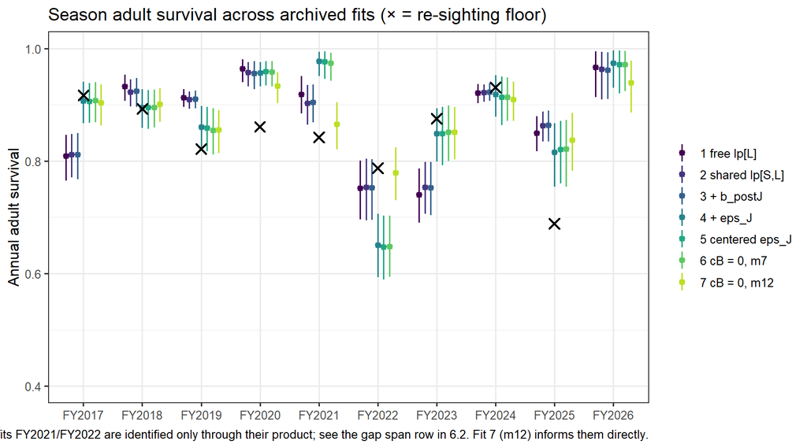

### 6.2 Juvenile survival offset and related parameters

`dJ` cannot be read in isolation: in fit 3 it sits on a ridge with `b_postJ` (only their sum is informed), and in fit 4 it is confounded with the mean of the uncentered `eps_J`. The derived rows put the fits on a common footing — annual L-stage survival at `mu_phi` including the mean season deviation where one exists, the 31-month adult survival across the scanner gap, and the S → L and L → A passage rates.

Posterior mean (95 % CI) by fit; — = not in that model

| Quantity | 1 free lp[L] | 2 shared lp[S,L] | 3 + b_postJ | 4 + eps_J | 5 centered eps_J | 6 cB = 0, m7 | 7 cB = 0, m12 |
| --- | --- | --- | --- | --- | --- | --- | --- |
| dJ (logit offset, L vs A) | -2.55 (-2.80–-2.31) | -2.98 (-3.28–-2.72) | -3.16 (-3.69–-2.67) | -2.63 (-3.91–-1.47) | -3.09 (-3.63–-2.62) | -3.15 (-3.57–-2.66) | -2.70 (-3.05–-2.34) |
| b_postJ[1, 2] (fit 3 only) | — | — | -0.68 (-1.17–-0.20) | — | — | — | — |
| dJ + b_post[J][1, 2] (netting-tagged, post-release) | -3.63 (-3.83–-3.45) | -3.82 (-4.00–-3.63) | -3.84 (-4.04–-3.64) | -3.32 (-4.55–-2.02) | -3.78 (-4.24–-3.32) | -3.82 (-4.17–-3.33) | -3.92 (-4.25–-3.60) |
| Annual L survival at mu_phi (+ mean eps_J) | 0.272 (0.087–0.496) | 0.140 (0.027–0.331) | 0.105 (0.009–0.292) | 0.123 (0.006–0.366) | 0.153 (0.012–0.409) | 0.137 (0.012–0.368) | 0.189 (0.066–0.347) |
| dS (S vs L) | -0.01 (-0.03–-0.00) | -0.03 (-0.12–-0.00) | -0.03 (-0.12–-0.00) | -0.03 (-0.13–-0.00) | -0.03 (-0.13–-0.00) | -0.03 (-0.12–-0.00) | -0.02 (-0.07–-0.00) |
| cB (density on juvenile survival) | 0.04 (-0.21–0.30) | -0.00 (-0.26–0.25) | 0.03 (-0.26–0.29) | -0.02 (-1.17–1.30) | -0.20 (-1.74–0.91) | — | — |
| sigma_phi (season adult SD) | 0.93 (0.53–1.59) | 0.85 (0.48–1.50) | 0.85 (0.48–1.46) | 1.08 (0.63–1.79) | 1.08 (0.62–1.83) | 1.05 (0.61–1.75) | 0.56 (0.29–1.00) |
| sigma_J (season juvenile SD) | — | — | — | 1.60 (0.91–2.55) | 1.63 (0.96–2.54) | 1.51 (0.91–2.38) | 1.09 (0.64–1.81) |
| Annual adult survival at mu_phi | 0.892 (0.816–0.944) | 0.889 (0.818–0.939) | 0.889 (0.817–0.938) | 0.900 (0.818–0.954) | 0.900 (0.817–0.953) | 0.899 (0.819–0.950) | 0.883 (0.836–0.921) |
| Annual adult survival FY2021 | 0.919 (0.884–0.950) | 0.903 (0.864–0.935) | 0.905 (0.868–0.936) | 0.977 (0.950–0.994) | 0.976 (0.946–0.995) | 0.974 (0.942–0.992) | 0.865 (0.821–0.904) |
| Annual adult survival FY2022 | 0.751 (0.696–0.801) | 0.753 (0.694–0.804) | 0.752 (0.696–0.803) | 0.651 (0.594–0.706) | 0.648 (0.589–0.703) | 0.648 (0.594–0.702) | 0.779 (0.730–0.824) |
| Adult survival Mar 2020 → Oct 2022 (31 mo) | 0.675 (0.627–0.720) | 0.663 (0.610–0.710) | 0.663 (0.613–0.712) | 0.619 (0.564–0.672) | 0.617 (0.563–0.669) | 0.615 (0.564–0.668) | 0.647 (0.598–0.694) |
| b_post[1, 2] (netting-tagged post-release) | -1.09 (-1.33–-0.83) | -0.84 (-1.08–-0.57) | -0.87 (-1.20–-0.55) | -0.68 (-0.99–-0.39) | -0.69 (-1.00–-0.38) | -0.67 (-0.96–-0.40) | -1.23 (-1.47–-0.97) |
| g_eff (effort slope on logit detection) | 0.44 (0.41–0.46) | 0.38 (0.35–0.40) | 0.38 (0.35–0.40) | 0.38 (0.35–0.40) | 0.20 (0.17–0.22) | 0.20 (0.17–0.23) | 0.13 (0.11–0.15) |
| Weekly detection S (lp[1, 1]) | 0.53 (0.51–0.54) | 0.45 (0.44–0.47) | 0.45 (0.44–0.47) | 0.45 (0.44–0.47) | 0.50 (0.49–0.52) | 0.50 (0.48–0.52) | 0.52 (0.51–0.54) |
| Weekly detection L (lp[1, 2]) | 0.17 (0.16–0.19) | 0.45 (0.44–0.47) | 0.45 (0.44–0.47) | 0.45 (0.44–0.47) | 0.50 (0.49–0.52) | 0.50 (0.48–0.52) | 0.52 (0.51–0.54) |
| Weekly detection A (lp[1, 3]) | 0.41 (0.40–0.42) | 0.43 (0.42–0.45) | 0.43 (0.42–0.45) | 0.43 (0.42–0.45) | 0.48 (0.46–0.49) | 0.47 (0.46–0.49) | 0.48 (0.47–0.49) |
| Monthly S → L probability | 0.279 (0.250–0.307) | 0.043 (0.021–0.083) | 0.047 (0.021–0.090) | 0.045 (0.020–0.086) | 0.057 (0.023–0.118) | 0.053 (0.023–0.119) | 0.081 (0.037–0.143) |
| Monthly L → A probability | 0.020 (0.014–0.027) | 0.115 (0.058–0.185) | 0.109 (0.056–0.183) | 0.102 (0.052–0.173) | 0.084 (0.040–0.156) | 0.086 (0.040–0.146) | 0.071 (0.042–0.115) |
| a1 (density on recruit size) | -1.84 (-2.19–-1.50) | -1.83 (-2.18–-1.50) | -1.84 (-2.18–-1.51) | -1.83 (-2.18–-1.48) | -1.82 (-2.17–-1.49) | -1.83 (-2.18–-1.48) | -1.84 (-2.19–-1.49) |

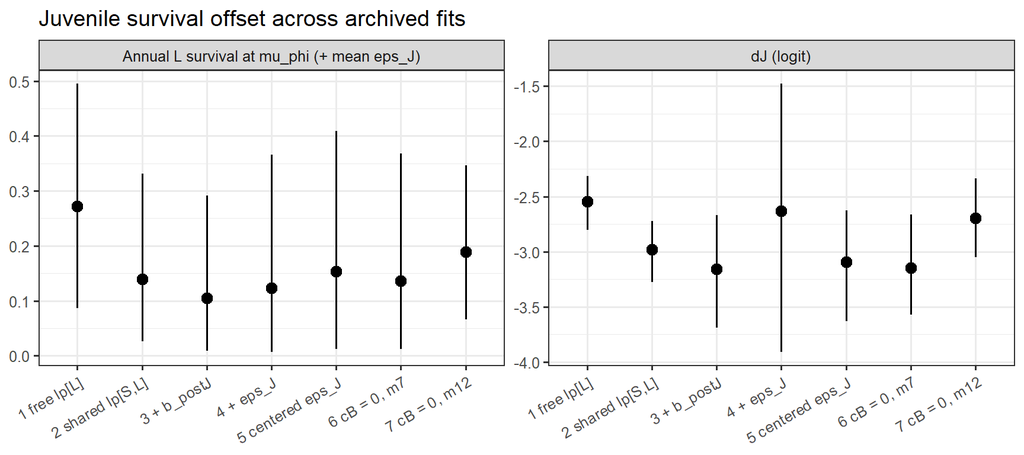

Reading across the sequence: sharing juvenile detection (fit 2) removed the low-detection L sink and moved its mass into `dJ`; the juvenile post-release offset (fit 3) changed nothing but created a `dJ`/`b_postJ` ridge; `eps_J` (fit 4) released adult survival in FY2017 and FY2023 toward their floors, at the cost of a `dJ`/mean(`eps_J`) confound; centering (fit 5) resolved that confound without moving survival — fit 5 was also the first on the screened data build (dead scanner weeks removed), which is what lifts weekly detection from about 0.45 to 0.50 for all stages; and dropping `cB` (fit 6) removed an unidentified parameter, again with no material change to survival. Adult survival in the well-scanned seasons and the 31-month gap product are stable across fits 4–6, which is the reassurance sought here: the reported survival does not depend on the parameterization choices made after `eps_J` was introduced. Fit 7 changes the data, not the model: with May–Sep months as primary periods, FY2021 and FY2022 separate (the m7 fits could only place their product), `sigma_phi` falls accordingly, and the netting-tagged post-release penalty `b_post[1, 2]` grows while `dJ` shrinks — the summer detections after a fall netting show that the loss of small fish is concentrated in the first months at large rather than spread across the year.

## 7. Comparison with the joint two-stage fit

Annual adult survival at YCB: three-stage fit vs joint two-stage fit (joint fit dated 2026-09-04)

| FY | 3-stage | 3S 2.5 % | 3S 97.5 % | Joint 2-stage | J 2.5 % | J 97.5 % | Floor |
| --- | --- | --- | --- | --- | --- | --- | --- |
| FY2017 | 0.903 | 0.863 | 0.935 | 0.744 | 0.700 | 0.787 | 0.917 |
| FY2018 | 0.901 | 0.870 | 0.929 | 0.916 | 0.892 | 0.937 | 0.893 |
| FY2019 | 0.856 | 0.814 | 0.890 | 0.780 | 0.755 | 0.805 | 0.821 |
| FY2020 | 0.933 | 0.903 | 0.957 | 0.958 | 0.942 | 0.971 | 0.861 |
| FY2021 | 0.865 | 0.821 | 0.904 | 0.856 | 0.827 | 0.882 | 0.842 |
| FY2022 | 0.779 | 0.730 | 0.824 | 0.761 | 0.719 | 0.800 | 0.787 |
| FY2023 | 0.851 | 0.803 | 0.896 | 0.576 | 0.528 | 0.621 | 0.875 |
| FY2024 | 0.909 | 0.871 | 0.941 | 0.814 | 0.786 | 0.839 | 0.931 |
| FY2025 | 0.837 | 0.782 | 0.885 | 0.695 | 0.660 | 0.728 | 0.689 |
| FY2026 | 0.939 | 0.886 | 0.978 | 0.980 | 0.940 | 0.998 | NA |

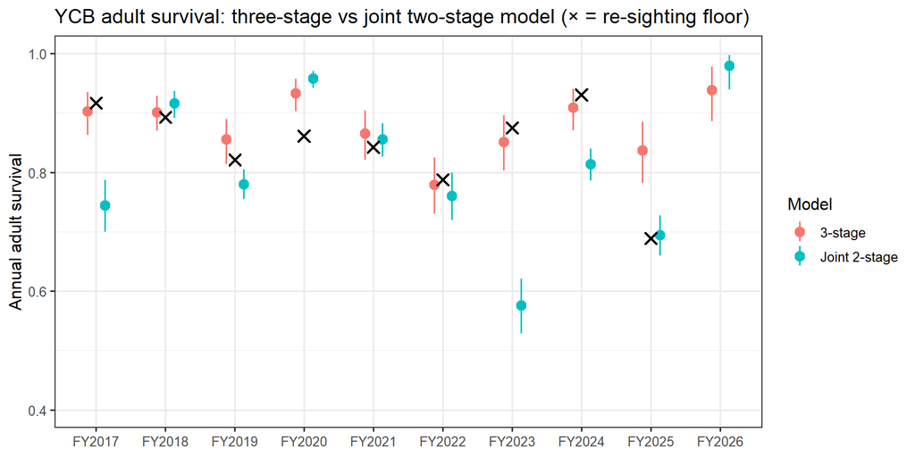

**Caveat:** the joint two-stage fit predates the current `BWRobustDesign_data.RData` build (scanner-week screening), so it was fitted on different detection availability. Refit the joint model before drawing quantitative conclusions from this comparison.

`sigma_phi[1]`: three-stage 0.56 (0.29–1.00) vs joint two-stage 1.39 (1.10–1.76).

## 8. Summary of validation status

- **Known-alive constraint:** satisfied in every month (120 of 120 months; smallest margin of the posterior mean 0.0 fish).
- **Adult survival vs floors:** no well-scanned season has a 97.5 % bound below its empirical floor.
- **Scanner-gap span (Mar 2020 → Oct 2022):** model 0.647 (0.598–0.694) vs floor 0.548.
- **Recruit size split:** 4 of 9 seasons have a posterior predictive p-value below 0.05.
- **Netting join:** 0 of 30 event-stage rows have a posterior predictive p-value below 0.05 (0 of 11 adult rows).
- **Convergence:** 26 monitored nodes with R-hat > 1.1 (max 1.29); species-1 hyperparameters max R-hat 1.04.

Open items carried forward from the model notes: the model is still above the direct floors on the two legs of the 2020–2022 gap that are unscanned on one side (April 2020 → April 2021, and the late-summer 2022 loss), because a season-constant monthly rate cannot localize mortality within a season; latent recruitment is not credibly identified; and pond surface area is still needed before the density covariate is comparable across ponds (Phase 4).